# NFO tree project demo

Derek Ouyang

9/16/2020

```r
library(tidyverse)
library(plotly)
library(sf)
library(tigris)
library(leaflet)
library(censusapi)
library(mapview)

Sys.setenv(CENSUS_KEY="c8aa67e4086b4b5ce3a8717f59faa9a28f611dab")
```

## Loading in parcel and building footprints

```r
smc_parcels <- readRDS("G:/Shared drives/SFBI/Data Library/Parcels/smc_parcels.rds")
```

Building footprints come either from OpenStreetMap (https://www.geofabrik.de/data/download.html) or from Microsoft (https://github.com/Microsoft/USBuildingFootprints). I tend to prefer OSM, but haven’t formally done any review of which is more ground-truth accurate in the region.

OSM is stored on G drive. Microsoft is easy to download from https://drive.google.com/drive/folders/1-XGvS25tQKKQ3HTqWjAfLJ4PaeXJ9yyY (Patty Frontiera, Berkeley)

```r
osm_bldg <- readRDS("G:/Shared drives/SFBI/Data Library/OSM/osm_bldg.rds")
```

Filter both to just NFO and save to our repo.

```r
nfo_boundary <-
  places("CA", cb = T, progress_bar = F) %>%
  filter(NAME == "North Fair Oaks")
```

```r
nfo_parcels <- smc_parcels[nfo_boundary, ]
nfo_bldgs <- osm_bldg[nfo_boundary, ]

saveRDS(nfo_parcels, "nfo_parcels.rds")
saveRDS(nfo_bldgs, "nfo_bldgs.rds")
```

Visualize, inspect

```r
ggplot(nfo_parcels) + geom_sf()
```

[output not shown]

If you use `mapview(nfo_parcels)` on your Console, it gives a nice simple leaflet style view, but currently the package seems to cause errors when knitting to web page, so the `ggplot()` method is bland but quick.

From `mapview()` inspection, it looks like there are some double-counted parcels (see the darker regions). Tthis might be because condominiumized parcels are plotted as the same overall parcel boundary. We’ll de-duplicate after joining with parcel data.

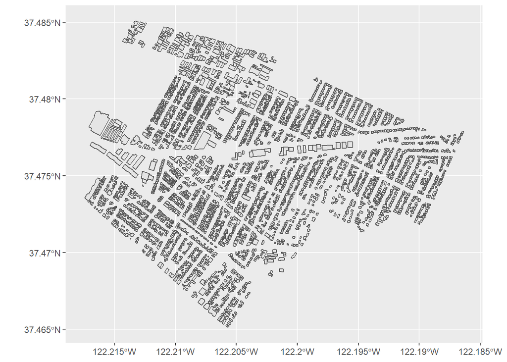

```r
ggplot(nfo_bldgs) + geom_sf()
```

## Loading in property data and joining to parcels

We have Assessor’s data directly from the County through our relationships. https://www.smcacre.org/assessor

In G Drive, SFBI-Restricted/SMC Assessor, there are many files. `secmstr` is the formal “assessor roll” data that includes ownership, property value, etc. Then there are “building characteristics files” that are broken up by type: `resident` for single family, `multifam`, `condo`, `office`, `hotel`, `industrial`, `mobilehome`. `smc_all.Rdata` holds on to all the various individual datasets in an R environment. `smc_assessor_full` combines of all the data into one file, joined by APN (parcel number). This yields 213 fields, so it’s quite unwieldy; it’s worth spending some time exploring the “format” spreadsheets here and understanding what information is available, and focusing in on what actually should be used for the purpose of our analyses.

BTW, `smc_assessor_full` happens to have the parcel shapes already pre-included, so we didn’t need the previous step actually.

```r
smc_assessor_full <- readRDS("G:/Shared drives/SFBI-Restricted/SMC Assessor/smc_assessor_full.rds")

nfo_parcels <-
  smc_assessor_full[nfo_boundary, ]

saveRDS(nfo_parcels, "nfo_parcels.rds")

write_csv(nfo_parcels, "nfo_parcels.csv")
```

```r
ggplot(nfo_parcels) + geom_sf()
```

[output not shown]

See what the duplicated geometries were.

```r
duplicates <-
  nfo_parcels %>%
  as.data.frame() %>%
  filter(
    geometry %in% (
      nfo_parcels %>%
         as.data.frame() %>%
         filter(duplicated(geometry)) %>%
         pull(geometry)
     )
  )

table(duplicates$`PUC CODE`)
```

```
##
## 12 97
##  2 74
```

According to the “PROPERTY CODE.pdf” in G drive, `12` is “store & office” and `97` is “residential condo”. We should ask Canopy generally whether any kinds of parcels are restricted (for example, is it just single family homes allowed to receive trees?). We haven’t explicitly asked this yet.

```r
nfo_parcels <-
  nfo_parcels %>%
  as.data.frame() %>%
  filter(!duplicated(geometry)) %>%
  st_as_sf()

ggplot(nfo_parcels) + geom_sf()
```

[output not shown]

Note that it may be worth it to do closer inspection of the region to identify parcels that should be considered special. For example, if a parcel is a park or public property that can be directly walked on, it shouldn’t be analyzed in the same way. Note there is a Hetch Hetchy pipe easement through the neighborhood, some of which is walkable area where folks have built urban gardens; probably should be treated in a special way. Some of this will be knowable once joining with Assessor data.

And as I noted, best to remove unnecessary fields at this point to make the data more wieldy.

## Loading in the sidewalk network

I’ll provide demos of actual sidewalk data soon, as it relates to getting foot traffic data, but first, here’s a convenient technique to take advantage of the original parcels being able to make the “block boundary” if you merge them together.

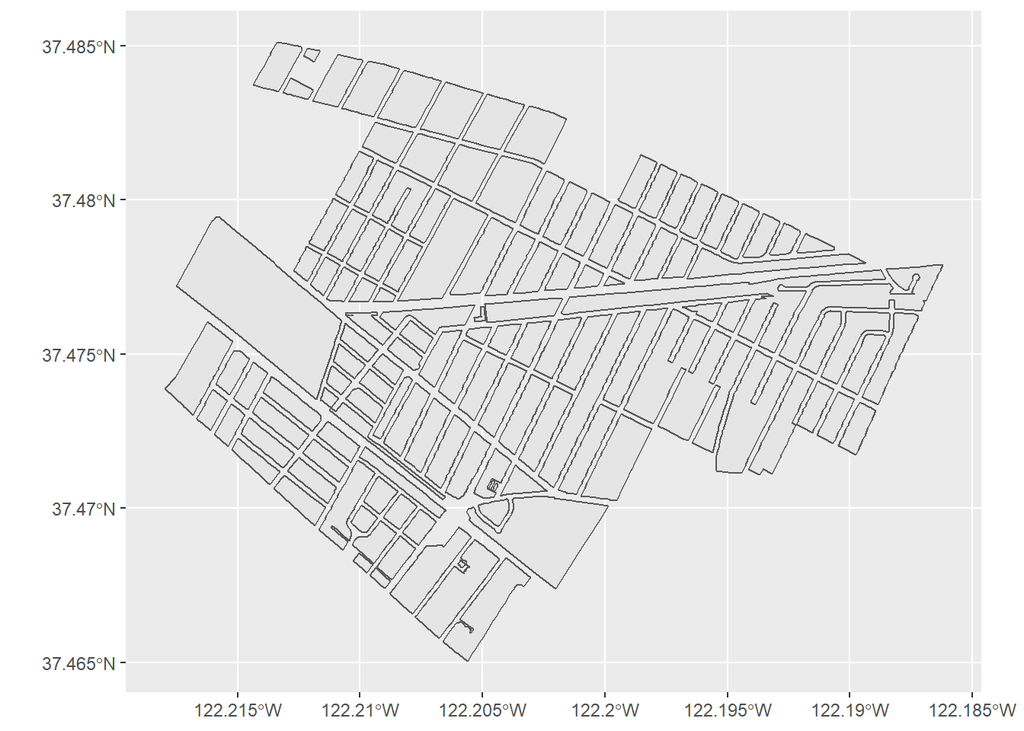

```r
nfo_blocks <-
  nfo_parcels %>%
  st_union()

ggplot(nfo_blocks) + geom_sf()
```

This can be further cleaned. But if you buffer this X feet in, then that becomes the “inside part of parcels” that aren’t optimal for sidewalk shading.

Need to make a projection system that is based in planar coordinates and ft units.

```r
projection <- "+proj=utm +zone=10 +ellps=GRS80 +datum=NAD83 +units=ft +no_defs"

nfo_nonsidewalk_yardarea <-
  nfo_blocks %>%
  st_transform(projection) %>%
  st_buffer(-10) %>%
  st_transform(4269)
```

## Doing geospatial manipulations of geometries to narrow down to a portion of interest

Let’s go ahead and buffer out on building footprints since trees can’t be too close to buildings. Assume 4ft for now.

```r
nfo_bldgs_buffer <-
  nfo_bldgs %>%
  st_transform(projection) %>%
  st_buffer(4) %>%
  st_transform(4269)
```

This demonstrates how to clip.

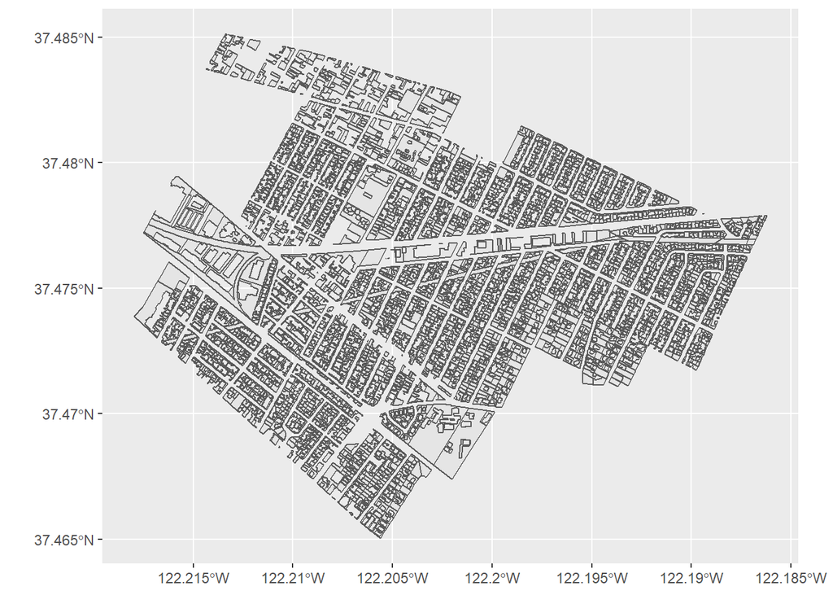

```r
nfo_yards <-
  nfo_parcels %>%
  st_difference(st_union(nfo_bldgs_buffer))

ggplot(nfo_yards) + geom_sf()
```

And clipping the non-sidewalk portions.

```r
nfo_yards_sidewalk_adjacent <-
  nfo_yards %>%
  st_difference(st_union(nfo_nonsidewalk_yardarea))

leaflet() %>%
  addTiles() %>%
  addPolygons(
    data = nfo_yards_sidewalk_adjacent,
    color = "black",
    weight = 0.5,
    fillColor = "green",
    label = ~APN
  )
```

[interactive chart not shown]

There may be other important geometry considerations like tree well size, some way to estimate driveway/paved portions, etc (possibly curb cut data exists out there. There could be info in the assessor fields that help us guess at width of driveway based on size of garage). Some parcels may have already been eliminated based on assessor data. Shading orientation relative to sun could be useful to factor in. Otherwise, the next section of analysis would start considering foot traffic and other transportation points of interest like bus stops.

## Loading in Safegraph data to identify origin-destination movement behavior

## Loading in Census/other data to estimate walking behavior

## Using OSRM to do walking routing